# Plots from Simulations (500 reps)

# Simulation setup

- Strata 1: D = 0.05 ; sigma = 200 m ; L0 = 2
- Strata 2: D = 0.0033 ; sigma = 3000 m ; L0 = 0.133

Here any estimates that are 20 fold or more out are excluded (other set is 5 times or more)

# Relative bias plots

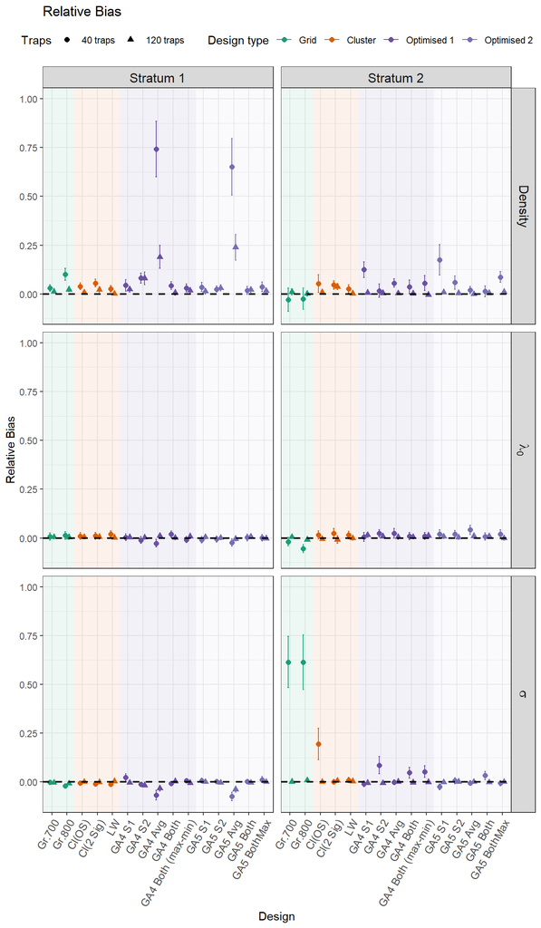

## General comments - bias

### Grids

- S1 and S2 D ests are skewed to the right for 800 m spacing but less so for 700 m
- For 800 m spacing S1 sigma skewed to the left and S2 sigma to the right, for 700 m S1 more symmetrical and S2 skewed to the right
- With 120 traps there are very few outliers for 700 m and 800 m spacing

### Clusters

- OS spacings: some skewness for S2 D and Sigma
- 2 * sigma spacing: slight positive skewness but balanced across the 2 strata
- With 120 traps there are very few outliers for OS spacing. With 2 sigma spacing there is slight +ve skew in D for both and some +ve skew in S2 L0 and sigmas are symmetrical

### GA4

#### S1 values

- Some positive skewness in D (more for S2), slight for L0 and sigma (more for S1)
- With 120 traps there are very few outliers

#### S2 values

- Slight positive skew in D and L0 for both strata, for sigma only for S2
- With 120 traps slight +ve skew in D for S1 but others fairly symmetrical

#### Both values

- Slight +ve skew across parameters (except for S1 sigma) but fairly balanced across strata
- Max-min similar
- With 120 traps dbns symmetrical with few outliers, for max-min there was slight +ve skew in the sigmas for both strata

### GA5

#### S1 values

- Some positive skewness in D (more for S2), slight for L0 and sigma fairly symmetrical
- With 120 traps the dbns are mostly symmetrical with few outliers

#### S2 values

- Slight positive skew in D for S2, in L0 for S1, in sigma for both
- With 120 traps very slight skew for S1 D otherwise symmetrical

#### Both values

- Very slight +ve skew in D for both, and sigma for S2
- Max-min similar for D but L0 and sigma are more symmetrical
- With 120 traps few outliers and mostly symmetrical dbns, same for max-min

### Lacework

- Very slight skew but mostly more symmetrical dbns for all parameters
- With 120 traps few outliers and mostly symmetrical dbns

# Excluded reps

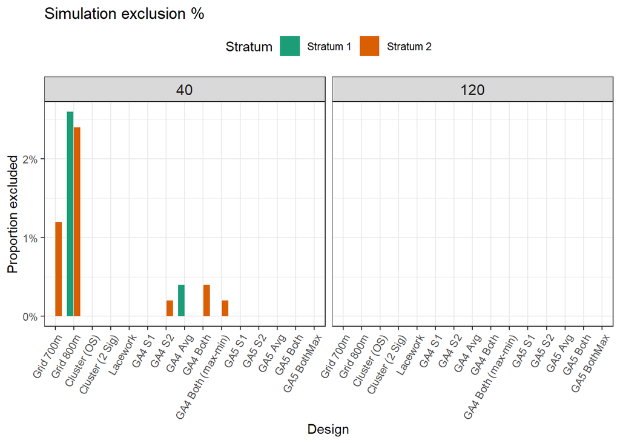

# Relative SE plots

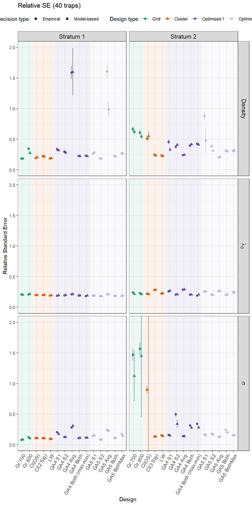

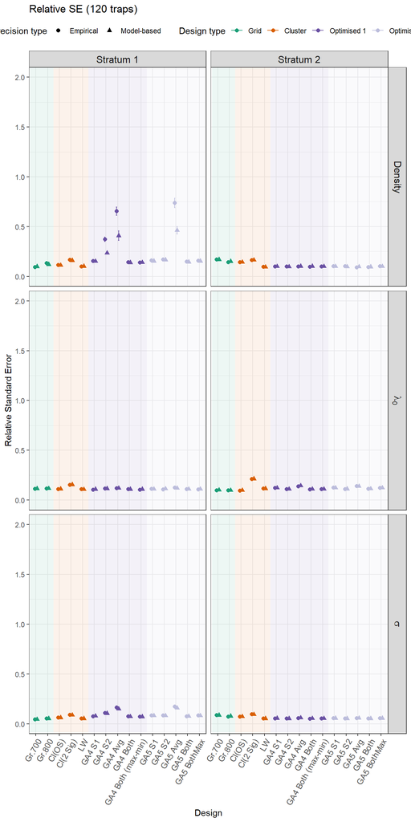

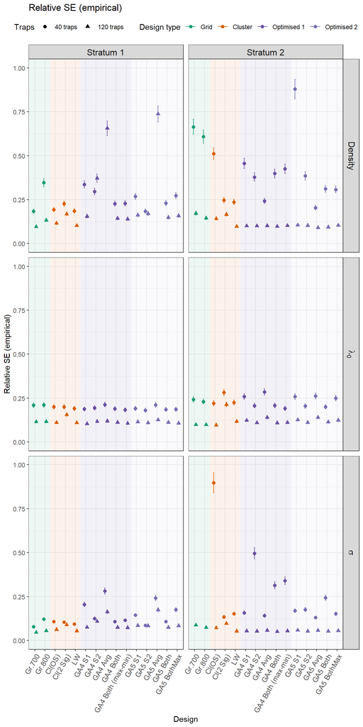

# Coverage plots

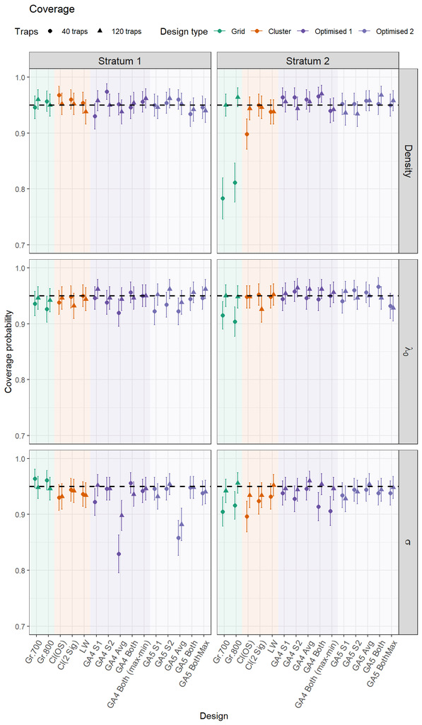

# Boxplots of estimates

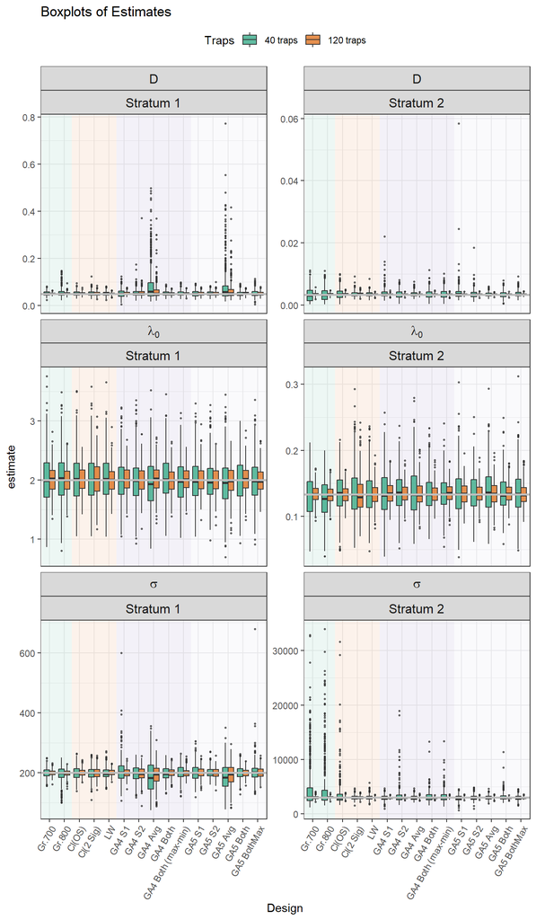

# Boxplots of standard errors

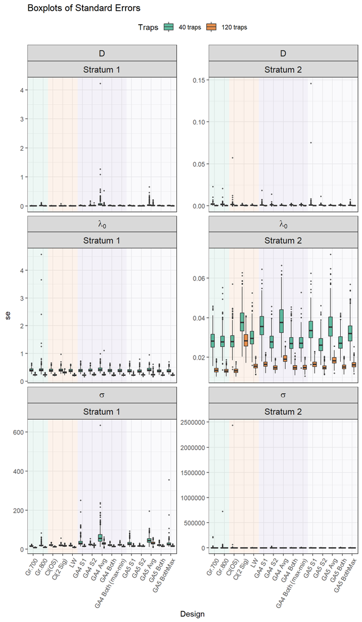

It is a little difficult to see what is going on in the consolidated plot, I think due to the small number of extreme values that stretches the axes. Here they are again with finer control per axis:

## Grids with 800 m spacing

**Density**

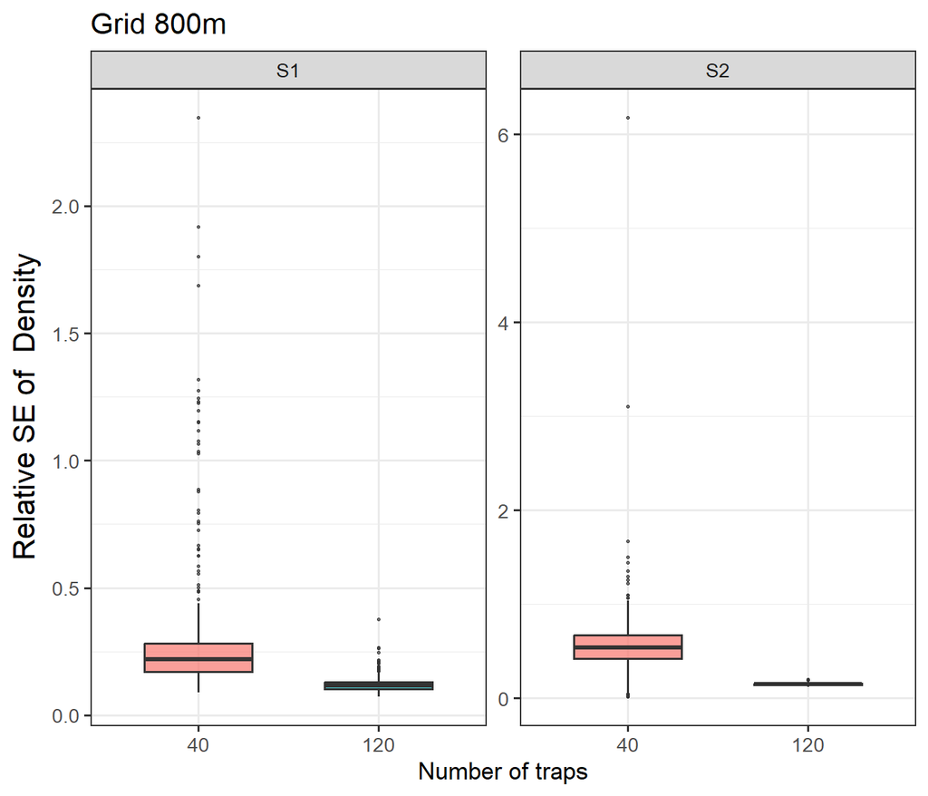

**λ₀**

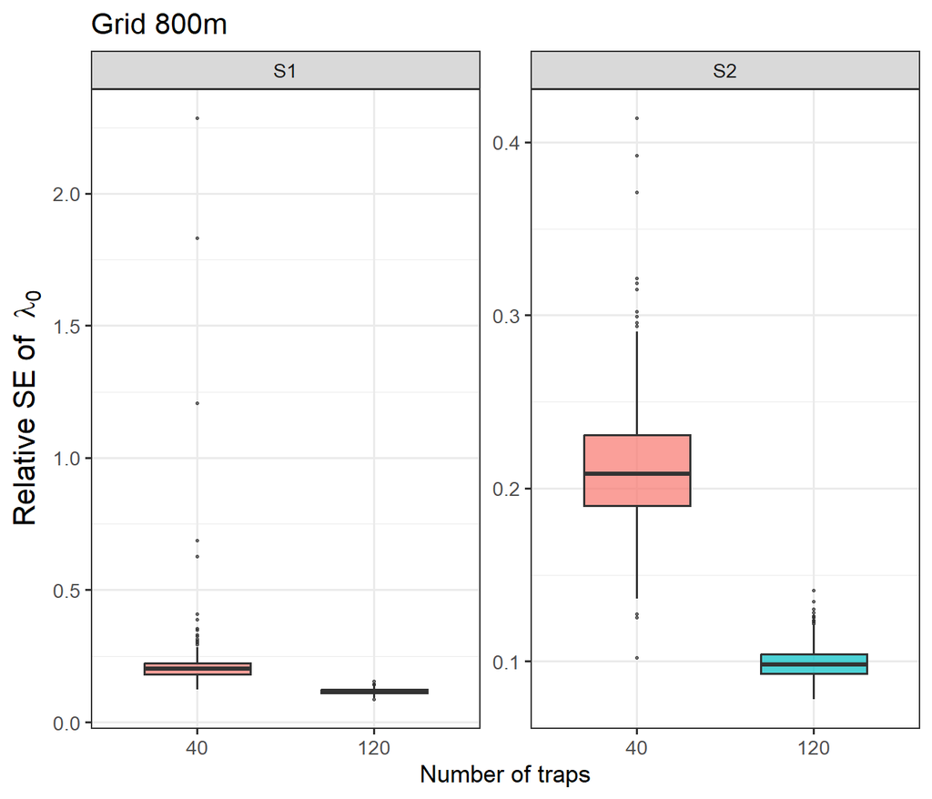

**σ**

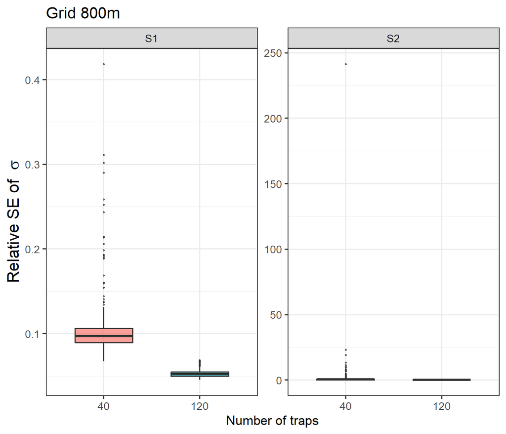

## Grids with 700 m spacing

**Density**

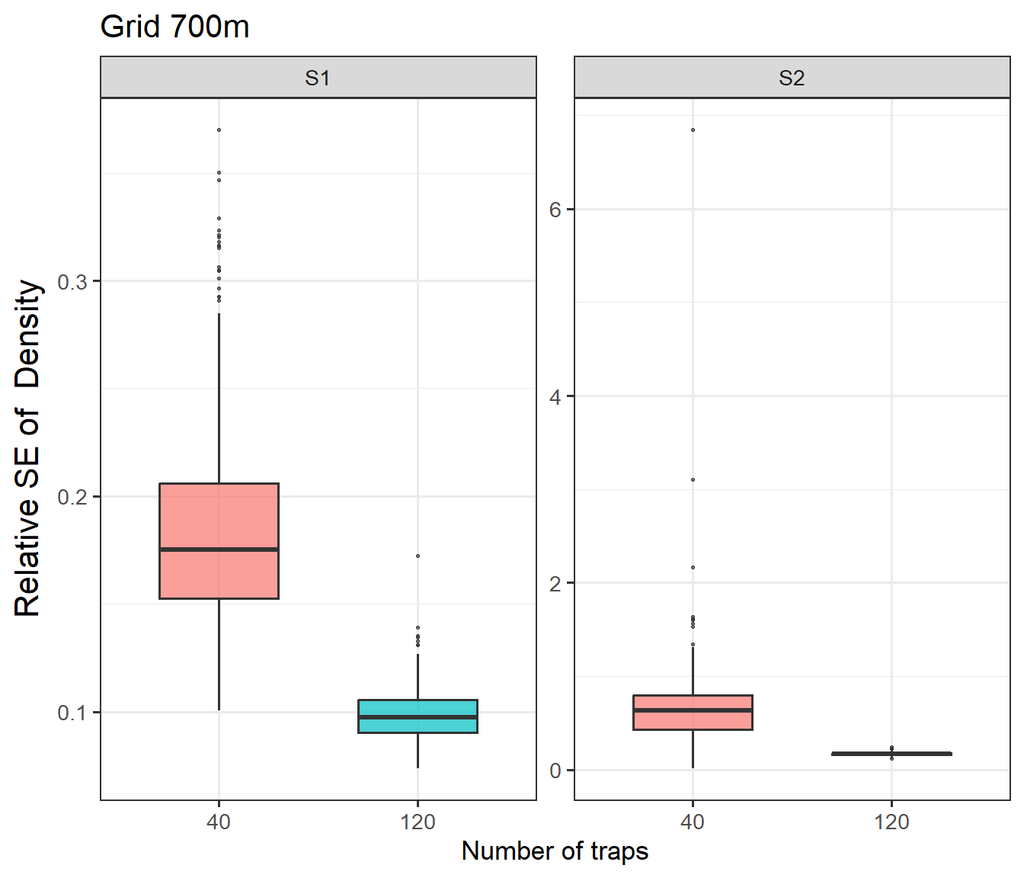

**λ₀**

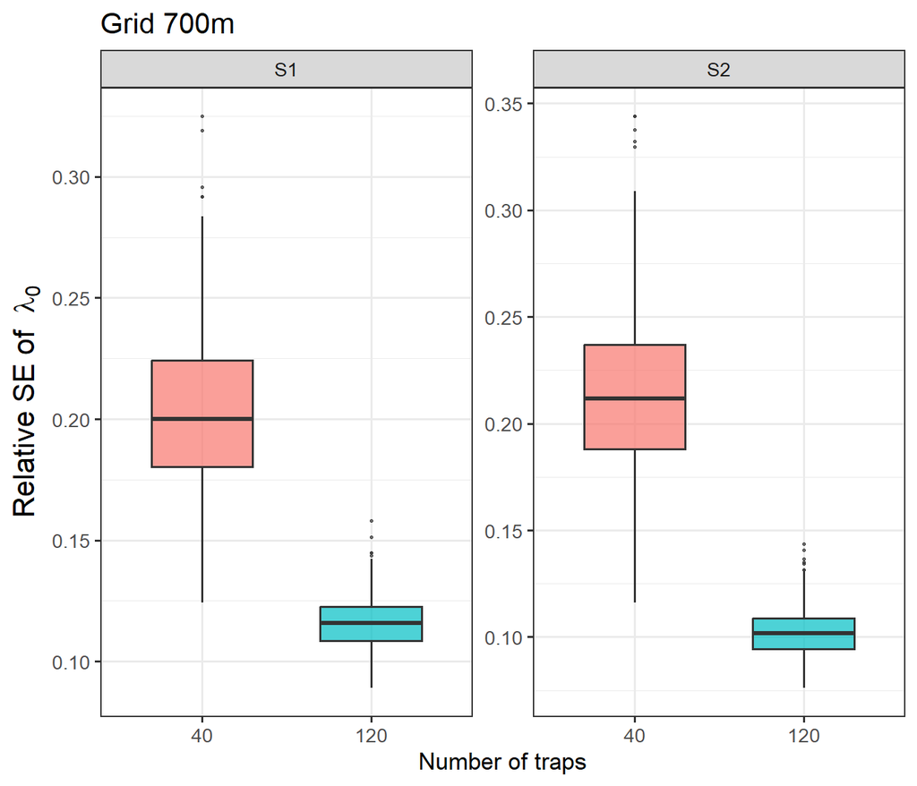

**σ**

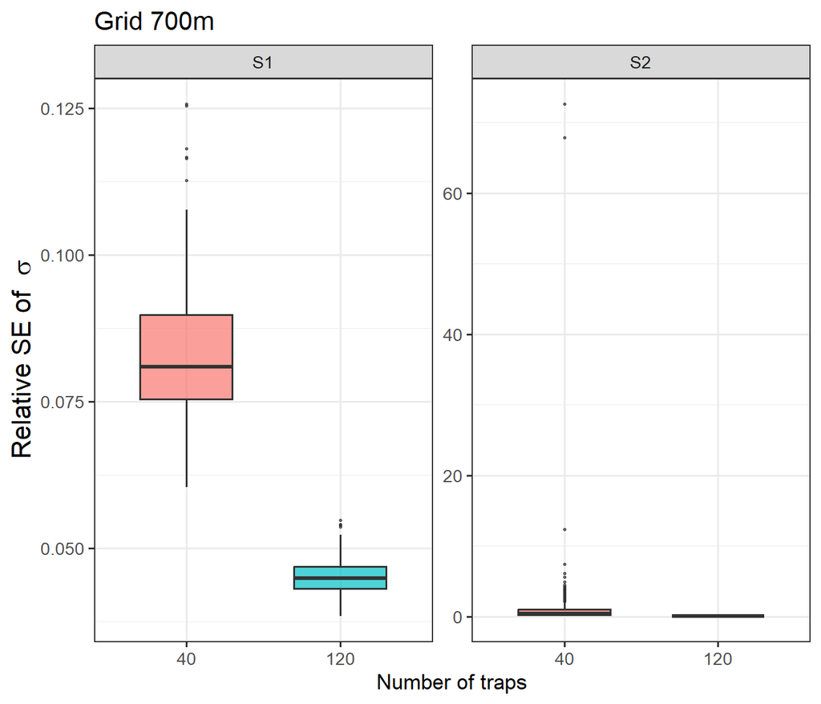

## Clusters - OS spacing

**Density**

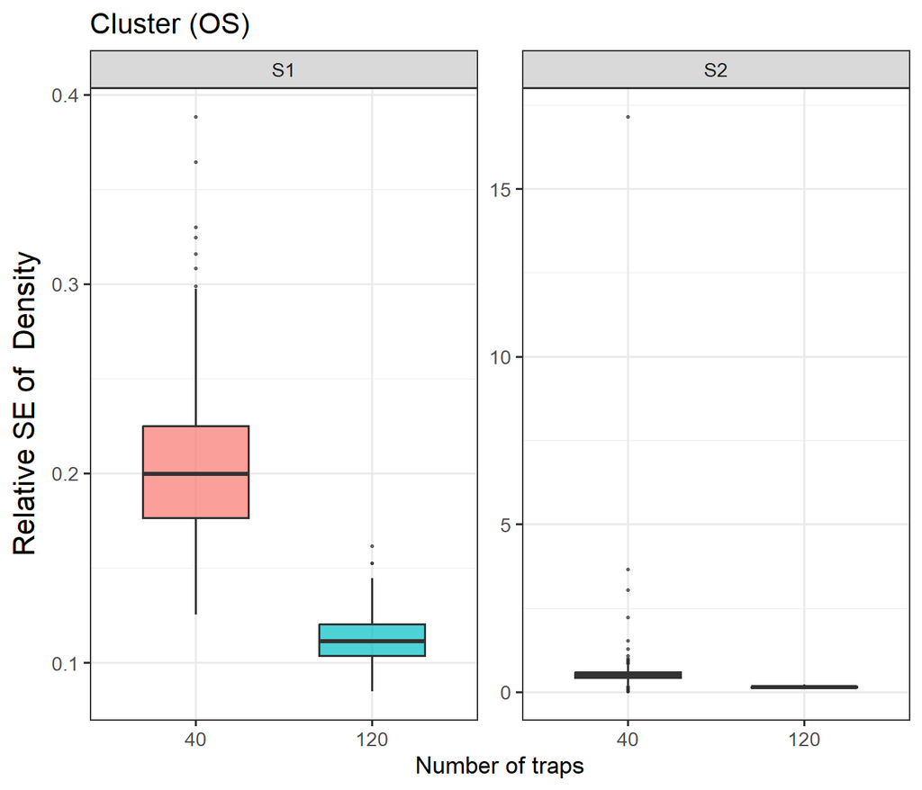

**λ₀**

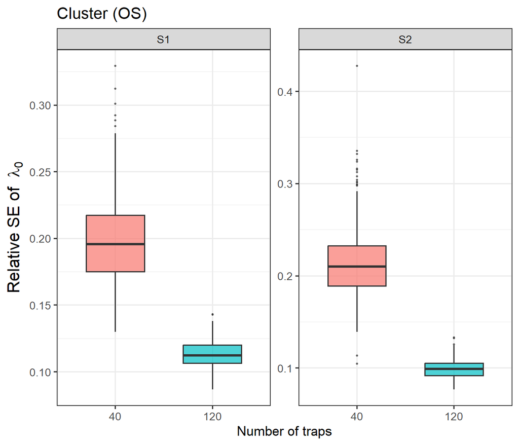

**σ**

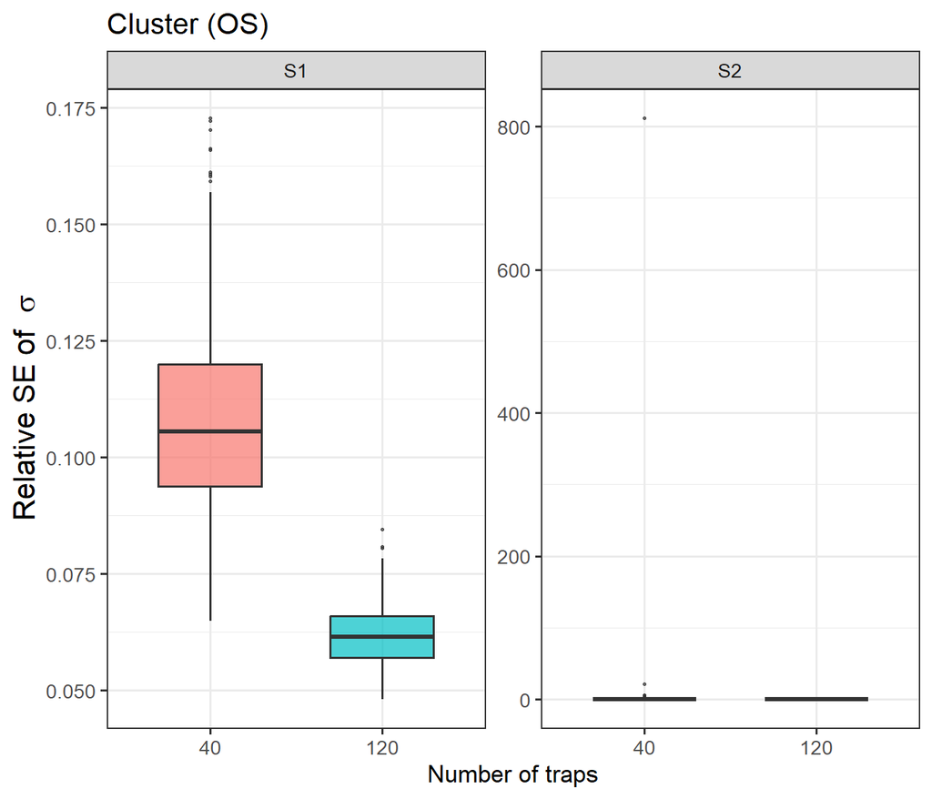

## Clusters - 2 sigma spacing

**Density**

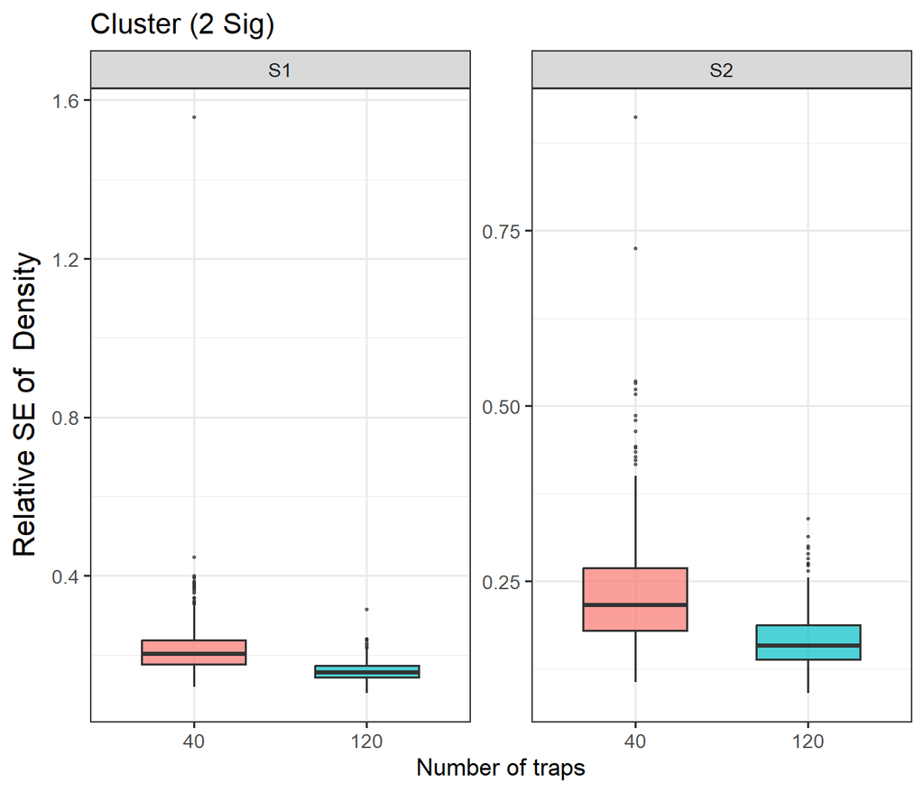

**λ₀**

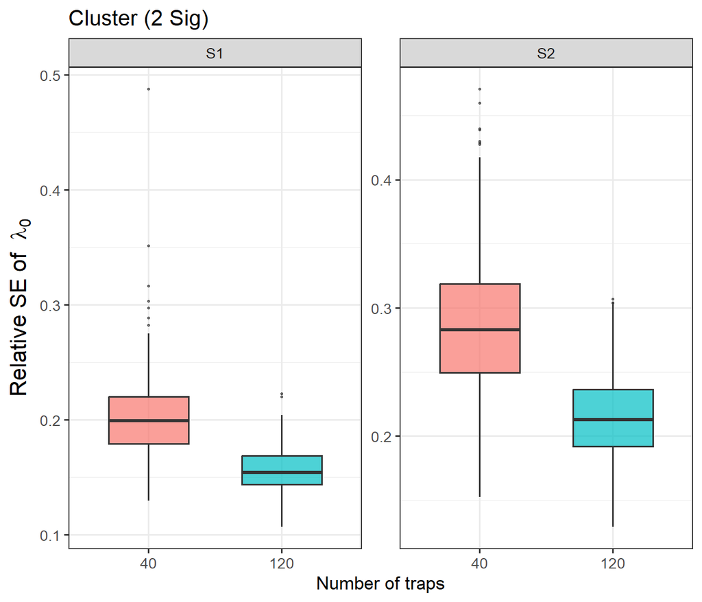

**σ**

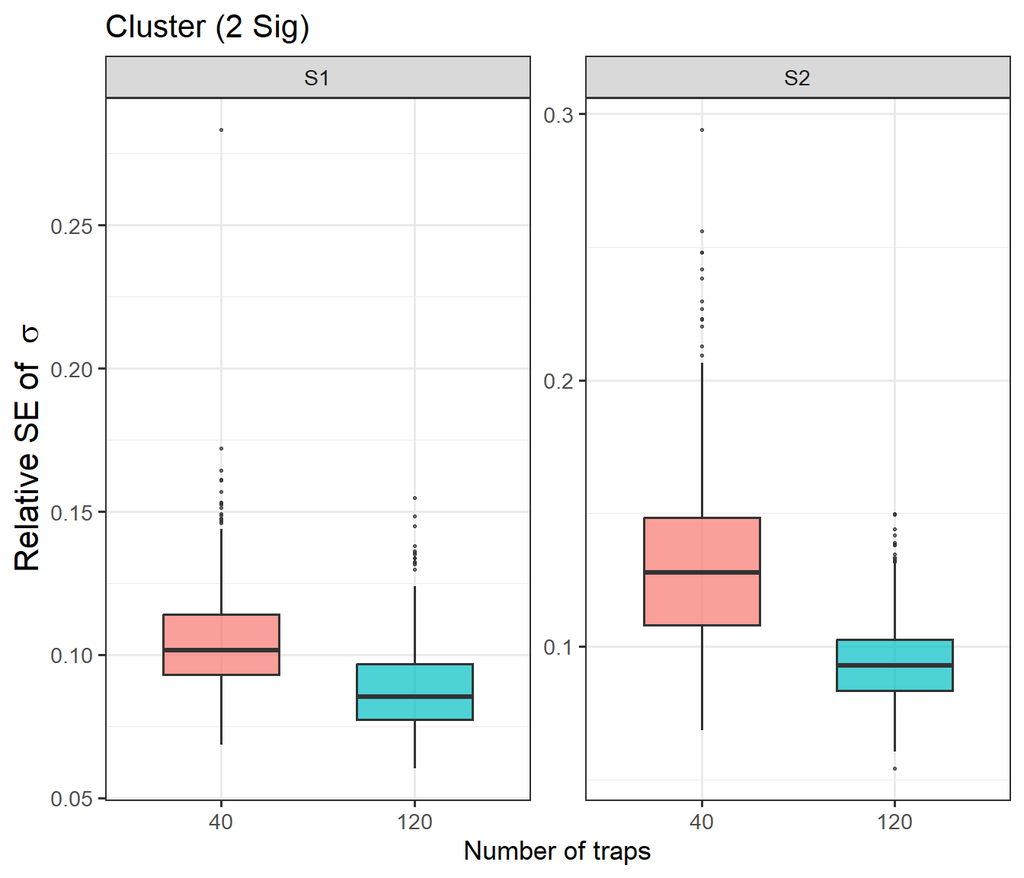

## GA4 - S1 values

**Density**

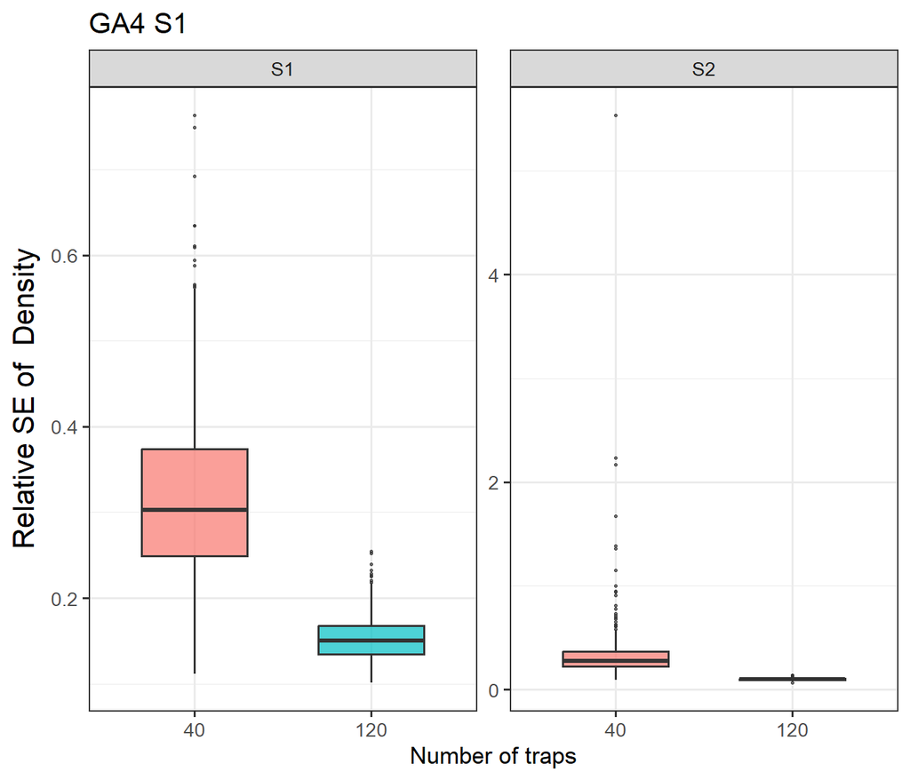

**λ₀**

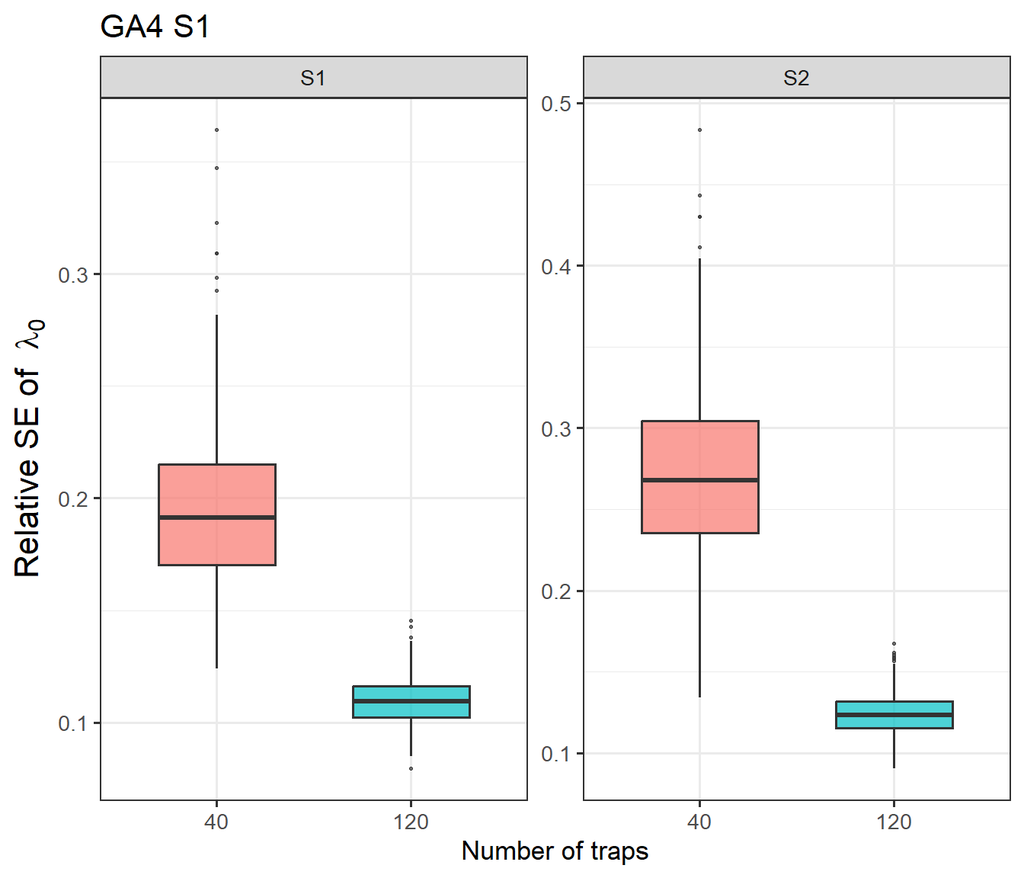

**σ**

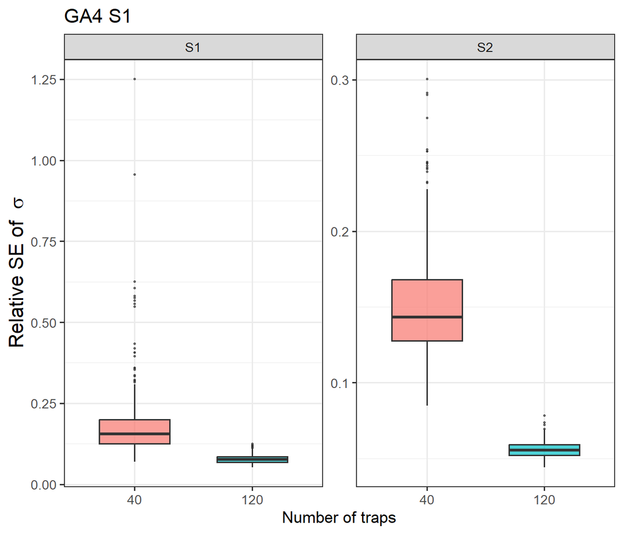

## GA4 - S2 values

**Density**

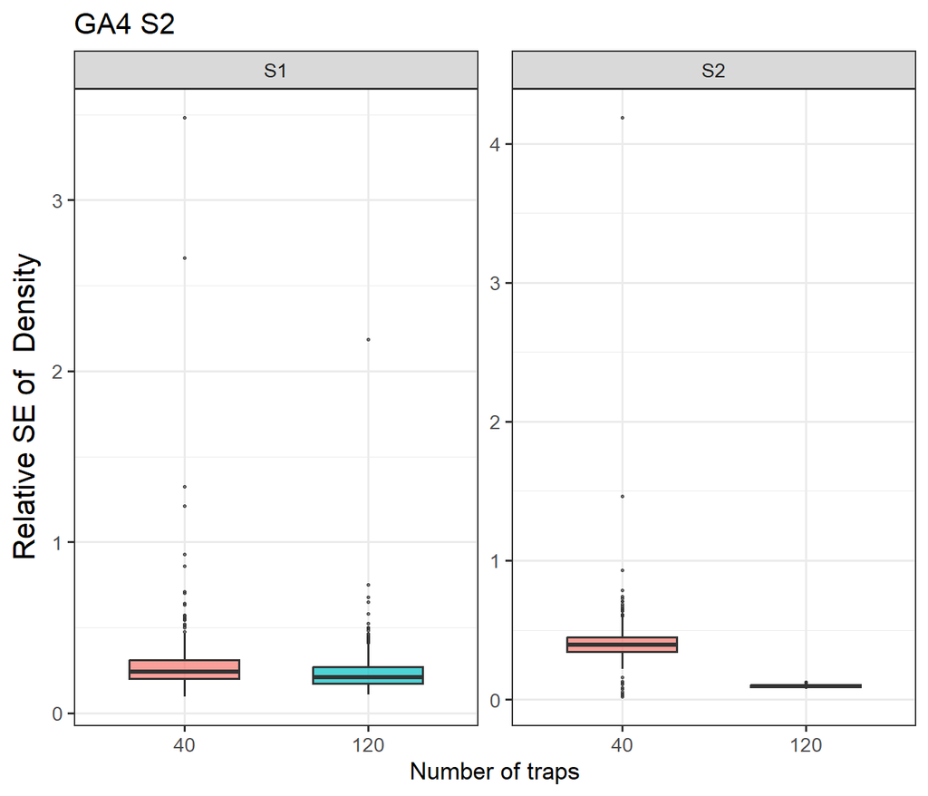

**λ₀**

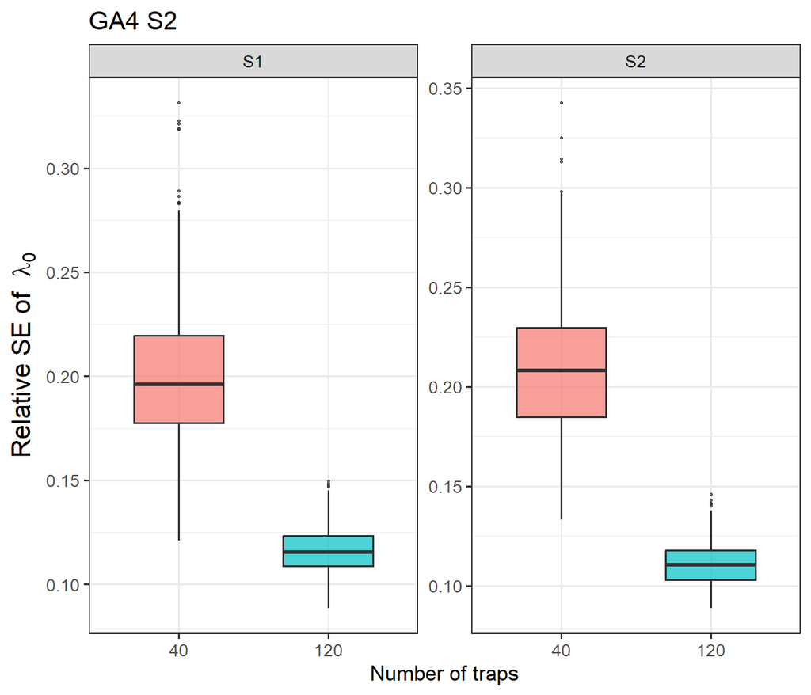

**σ**

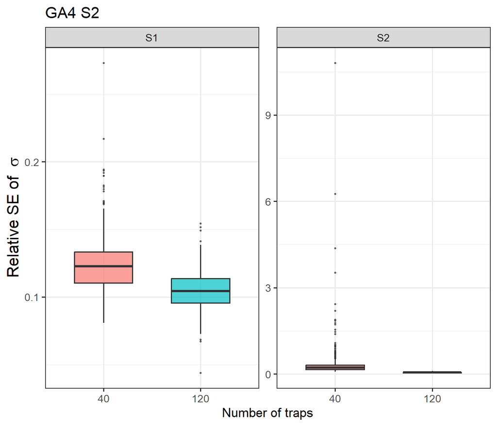

## GA4 - Avg values

**Density**

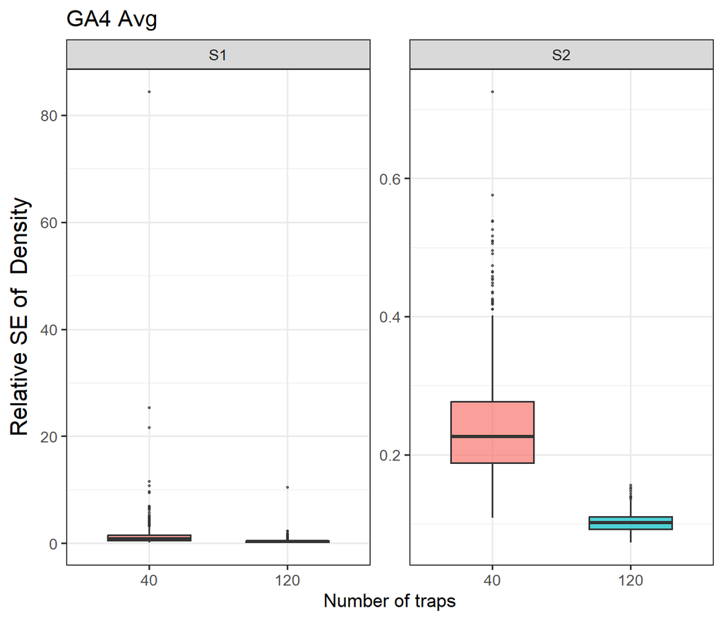

**λ₀**

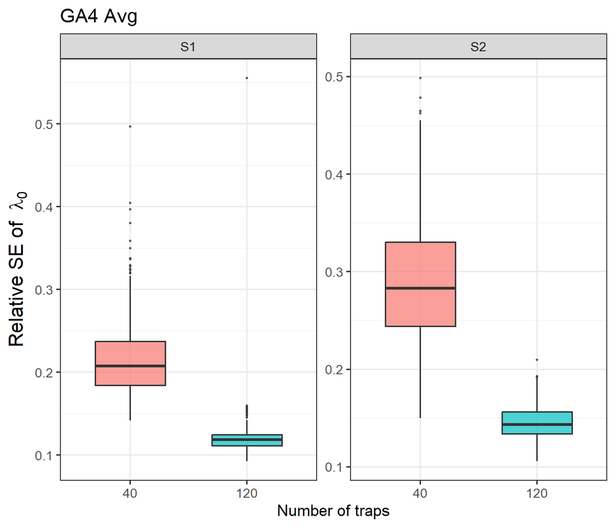

**σ**

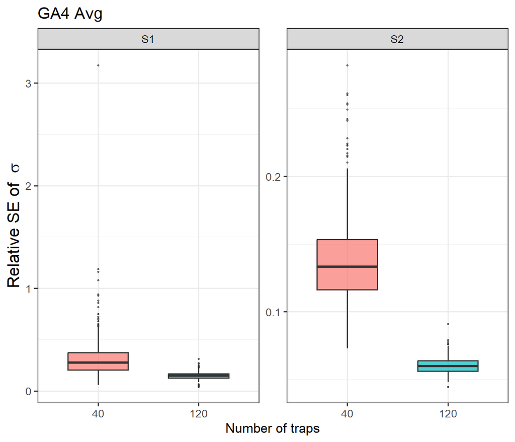

## GA4 - Both values

**Density**

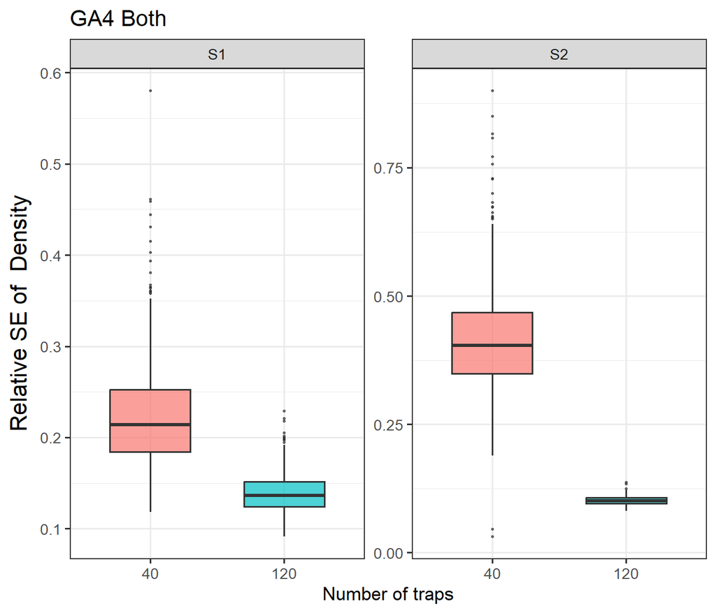

**λ₀**

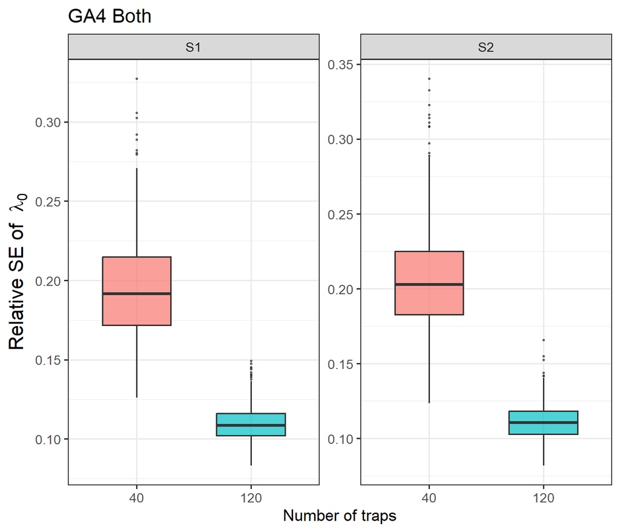

**σ**

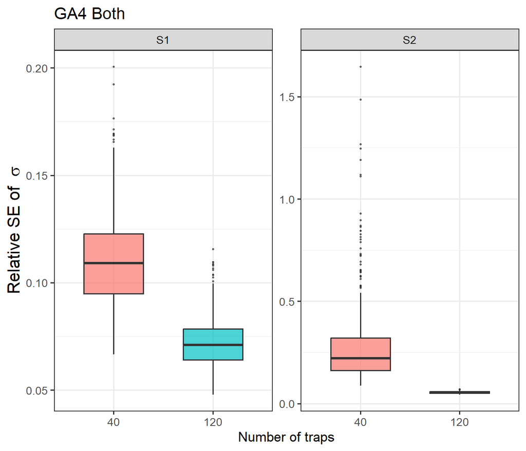